# Pediatric dose evaluation

Metrum Research Group, LLC

# Packages

- Loading some packages
- Sourcing in some code in `functions.R`

```r
a <- config::get()
source(a$functions)
library(dplyr)
library(ggplot2)
library(mrgsolve)
library(tidyr)
```

# Publication

- Title: *Population pharmacokinetics of azithromycin and chloroquine in healthy adults and paediatric malaria subjects following oral administration of fixed-dose azithromycin and chloroquine combination tablets*
- Authors: Qinying Zhao, Thomas G Tensfeldt, Richa Chandra, Diane R Mould
- Reference: Malaria Journal 2014, 13:36

## Conclusion

“Weight was predictive of exposure for both AZ and CQ. Assuming equivalent dosing (mg/kg), AZ and CQ exposure in children would be expected to be lower than that in adults, suggesting that children may require a higher dose (mg/kg) than adults to achieve the same AZ and CQ exposure.”

## Our objective

- Explore this conclusion through simulation
- If we used the typical adult mg/kg dose in a pediatric population, is the AUC really that different? How much different?

# Simulated ages and weight

```r
data <- readRDS(a$az_datafile)

head(data)
```

```
.    AGE       WT ID
. 1 49.4 67.69870  1
. 2 49.6 85.26429  2
. 3  7.5 40.95103  3
. 4 21.1 87.99726  4
. 5 35.6 57.14894  5
. 6 30.4 90.89950  6
```

Derive a grouping variable based on `AGE`

- 1 = `0.5 <= AGE < 5`
- 2 = `5 <= AGE <= 12`
- 3 = `AGE >= 18`

```r
data <- mutate(data,
               group = case_when( AGE >= 0.5 & AGE < 5 ~ 1,
                                  AGE >= 5 & AGE <= 12 ~ 2,
                                  AGE >=18 ~ 3))

data <- filter(data, !is.na(group))
```

# Azithrymycin dosing

Modify this covariate data frame so that we have

- oral, bolus doses
- daily dosing over 3 days

```r
data <- mutate(data, cmt=1, ii=24, addl=2, time=0, evid=1) %>% as_data_frame
```

- Sample 2000 subjects in each of the age groups

```r
data <- group_by(data, group) %>% sample_n(2000) %>% ungroup
head(data)
```

```
. # A tibble: 6 x 9
.     AGE       WT    ID group   cmt    ii  addl  time  evid
.   <dbl>    <dbl> <int> <dbl> <dbl> <dbl> <dbl> <dbl> <dbl>
. 1   3.0 26.71907 87816     1     1    24     2     0     1
. 2   3.1 28.40886 62143     1     1    24     2     0     1
. 3   2.9 26.51702 54793     1     1    24     2     0     1
. 4   1.8 15.80110  8259     1     1    24     2     0     1
. 5   1.2 14.48276  9678     1     1    24     2     0     1
. 6   3.1 25.01542 67488     1     1    24     2     0     1
```

Assign doses

- For the pediatric cohorts, 300 mg if weight > 20 kg and 100 mg otherwise
- For adults, 500 mg
- doses are daily x 3 days

```r
data <- mutate(data, dose = if_else(WT > 20, 300, 100))
data <- mutate(data, dose = if_else(group==3, 500, dose), dosekg = dose/WT)
```

The doses were assigned into `dose`; we need to copy that into `amt` as well

```r
data <- mutate(data, amt = dose)
head(data)
```

```
. # A tibble: 6 x 12
.     AGE       WT    ID group   cmt    ii  addl  time  evid  dose    dosekg
.   <dbl>    <dbl> <int> <dbl> <dbl> <dbl> <dbl> <dbl> <dbl> <dbl>     <dbl>
. 1   3.0 26.71907 87816     1     1    24     2     0     1   300 11.227936
. 2   3.1 28.40886 62143     1     1    24     2     0     1   300 10.560086
. 3   2.9 26.51702 54793     1     1    24     2     0     1   300 11.313490
. 4   1.8 15.80110  8259     1     1    24     2     0     1   100  6.328674
. 5   1.2 14.48276  9678     1     1    24     2     0     1   100  6.904760
. 6   3.1 25.01542 67488     1     1    24     2     0     1   300 11.992604
. # ... with 1 more variables: amt <dbl>
```

# Azithromycin model

```r
mod <- mread(a$az_model, a$az_project)

see(mod)
```

```
.
. Model file:  azithro.cpp
.  [PROB]
.  # Population pharmacokinetics of azithromycin
.  and chloroquine in healthy adults and paediatric
.  malaria subject following oral administration of
.  fixed-dose azithromycin and chloroquine combination
.  tablets
.
.
.  [SET] end=10*24, delta=0.1
.
.  [PARAM] @annotated
.  TVCL :   100 : Typical value of clearance (L/h)
.  TVV1 :   186 : Typical central volume of distribution (L)
.  TVQ2 :   180 : Typical intercomp clearance 1 (L/h)
.  TVV2 :  2890 : Typical peripheral volume of distribution 1 (L)
.  Q3   :  10.6 : Intercomp clearance 2 (L/h)
.  V3   :  2610 : Peripheral volume of distirbution 2 (L)
.  KA   : 0.259 : Absorption rate constant (1/h)
.  WT   :    70 : Patient weight (kg)
.
.  [CMT] @annotated
.  GUT  : Dosing compartment (mg)
.  CENT : Central comaprtment (mg)
.  PER2 : First peripheral compartment (mg)
.  PER3 : Second peripheral compartment (mg)
.
.  [OMEGA] @annotated @block
.  ETACL : 0.097969 : ETA on clearance
.  ETAV1 : 0.280000 1.2769 : ETA on V1
.
.
.  [MAIN]
.  double CL = TVCL*pow(WT/70.0,0.75)*exp(ETACL);
.  double V1 = TVV1*(WT/70)*exp(ETAV1);
.  double Q2 = TVQ2*pow(WT/70.0,0.75);
.  double V2 = TVV2*(WT/70.0);
.
.  [SIGMA] @annotated
.  RUV : 0 : Residual unexplained variability
.
.  [ODE]
.  dxdt_GUT  = -KA*GUT;
.  dxdt_CENT =  KA*GUT - (CL+Q2+Q3)*CENT/V1 + Q2*PER2/V2 + Q3*PER3/V3;
.  dxdt_PER2 =  Q2*(CENT/V1 - PER2/V2);
.  dxdt_PER3 =  Q3*(CENT/V1 - PER3/V3);
.
.  [TABLE]
.  capture CP = CENT/(V1/1000.0)*exp(RUV);
.
.
```

Update the model object to cover 3 days of dosing

```r
mod <- update(mod, end=72, delta=0.2)
```

## Simulate all age groups

```r
sims <- mrgsim(mod, data = data, obsonly = TRUE, Req = "CP")
```

Some post-processing to calculate the `AUC` on `DAY` 3

```r
sims <- mutate(sims, DAY = 1+floor(time/24)) %>% filter(DAY==3)

auc <- AUC(sims, time="time", dv="CP") %>% left_join(data)
```

Now, dose normalize the AUC (and switch up the units)

```r
auc <- mutate(auc, ratio  = AUC/dosekg/1000)

head(auc)
```

```
.    ID      AUC  AGE        WT group cmt ii addl time evid dose   dosekg
. 1  37 2258.283 23.0 107.50749     3   1 24    2    0    1  500 4.650839
. 2  41 4041.808  3.6  44.29238     1   1 24    2    0    1  300 6.773174
. 3  89 4423.338 43.5  72.06162     3   1 24    2    0    1  500 6.938506
. 4 103 4165.707 21.8  75.84173     3   1 24    2    0    1  500 6.592677
. 5 117 2831.789 10.2  60.50957     2   1 24    2    0    1  300 4.957894
. 6 166 6368.088 19.7  51.06062     3   1 24    2    0    1  500 9.792282
.   amt     ratio
. 1 500 0.4855647
. 2 300 0.5967377
. 3 500 0.6375058
. 4 500 0.6318688
. 5 300 0.5711677
. 6 500 0.6503171
```

Mark the adult group for the plot

```r
auc <- mutate(auc, pop  = if_else(group==3, "adult", "pediatric"))
```

## Plot

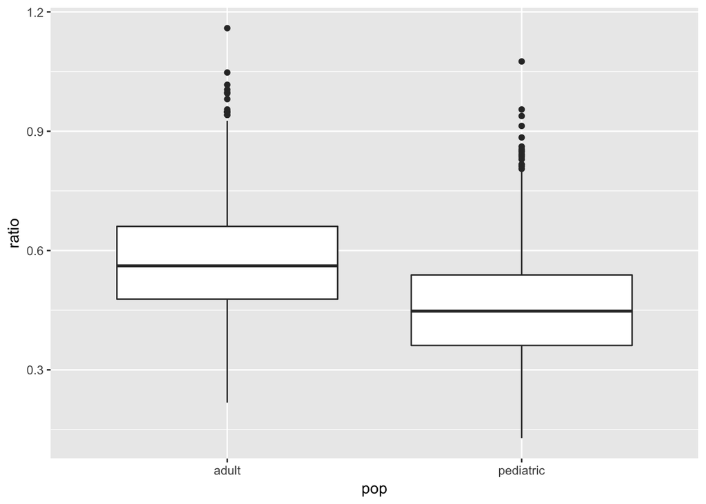

```r
ggplot(data=auc, aes(x=pop, y=ratio)) + geom_boxplot()
```

# Your turn

Find the typical per/kg dose in the adult population and apply that dose to the 6 - 59 month population

```r
auc %>% group_by(group) %>% summarise(mean = mean(dosekg))
```

```
. # A tibble: 3 x 2
.   group     mean
.   <dbl>    <dbl>
. 1     1 9.625905
. 2     2 6.359560
. 3     3 6.741041
```

Let’s take 7 mg/kg and simulate out 6 to 59 month old kids next to adults What is the distribution of the adult/pediatric auc ratio

```r
data4 <- filter(data, group != 2) %>% mutate(amt = WT*7)
```

```r
sims <- mrgsim(mod, data = data4, obsonly = TRUE, Req = "CP")

sims <- mutate(sims, DAY = 1 + floor(time/24)) %>% filter(DAY==3)

auc <- AUC(sims, time="time", dv="CP")

auc <-
  left_join(auc, data4) %>%
  group_by(group) %>%
  mutate(unit = 1:n()) %>%
  ungroup

auc <-
  dplyr::select(auc, unit, AUC, group ) %>%
  spread(group, AUC, sep = "")

auc <- mutate(auc, ratio = group1/group3)
```

Summarize

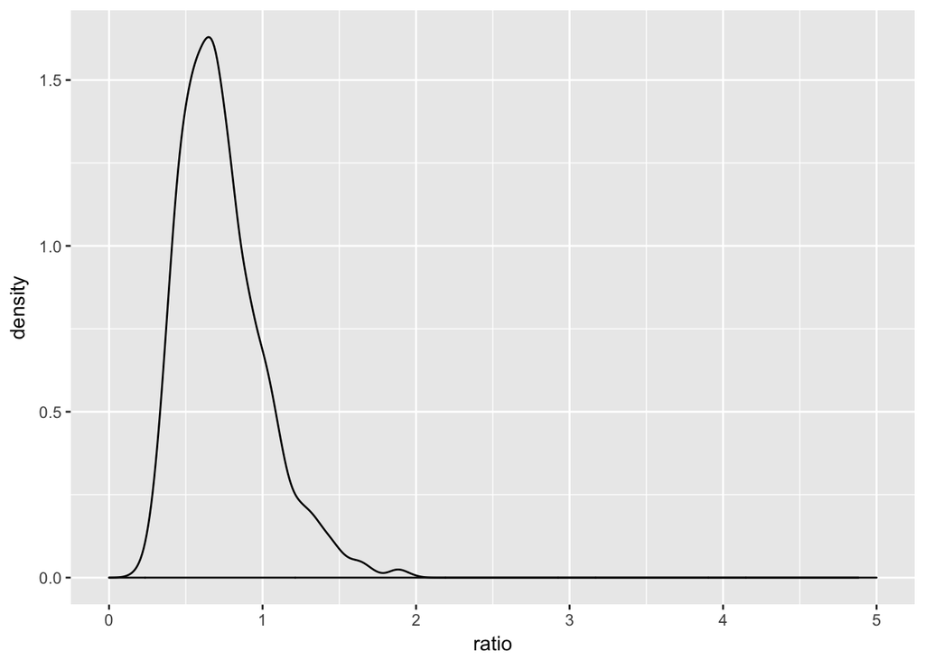

```r
ggplot(data=auc, aes(x=ratio)) + geom_density() + xlim(0,5)
```

```r
summarize(auc,
          mean = mean(ratio),
          lower = quantile(ratio, 0.025),
          upper = quantile(ratio, 0.975))
```

```
. # A tibble: 1 x 3
.        mean     lower    upper
.       <dbl>     <dbl>    <dbl>
. 1 0.7364983 0.3359266 1.417301
```

```r
mean(auc$ratio < 1)
```

```
. [1] 0.8375
```